# Project Proposal

2020-10-13

## Introduction

Australia has experienced a regular occurrence of bushfires every year which played a major role in defining the country’s geographical characteristics that we see now. Due to its high temperatures and low humidity, Australia’s climate has become more ideal for widespread bushfires.

## Motivation & Objectives

Past research only covered certain states in Australia and they were more relevant for less intense bushfires. Most of them do not show much in-depth analysis of the Black Summer in 2019 and were mostly focused on the relationship between weather factors and the severity of bushfire without analysing the spread of bushfire over time. Thus our group felt the need to expand the scope of the research to the whole of Australia while covering the bushfire season that occurred in 2019.

## Literature review

Geographical pattern analysis of bushfire severity in Southern Australia by University of Tasmania. This research paper focuses on the bushfires in Tasmania that occurred in 2013 and how its temporal patterns of fire severity are related to changes in the fire weather.

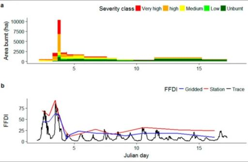

```r
knitr::include_graphics(rep('img/lit_review.jpg'))
```

As shown in the above figure, it is evident that the fire severities pattern is in tandem with that of Forest Fire Danger Index(FFDI), which takes in factors that attribute towards forest fires such as humidity level, rainfall and temperature.

## Methodology

### Data Wrangling

August to September bushfire dataset (CSV) and October to January bushfire dataset (CSV)

- Convert latitude and longitude variables to geometry points
- Assign CRS to match Australian States dataset (EPSG 4326)
- Check for NA values
- Check for invalid geometry
- Prepare dataset for Spatial Point Pattern analysis: Converting to spatstat’s ppp format & Checking for duplicated points byApply jittering approach to handle duplicated points Ready to be combined with study area for analysis

Source: https://www.kaggle.com/carlosparadis/fires-from-space-australia-and-new-zeland

Australian States (SHP) - Check for NA values - Check for invalid geometry - Prepare dataset for Spatial Point Pattern analysis: Convert to owin & combine with bushfire data points for analysis

Source: https://www.arcgis.com/home/item.html?id=66e2eac498084e218dee3a8a7f625f5f

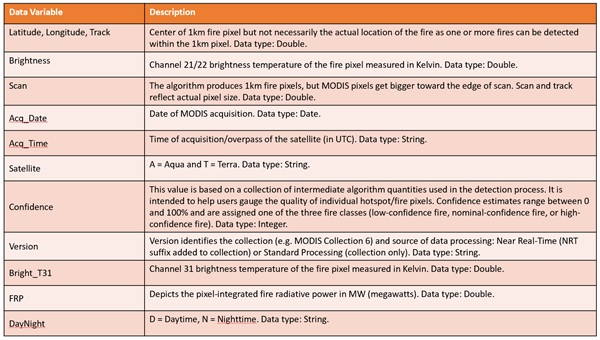

```r
knitr::include_graphics(rep('img/Data_variables.jpg'))
```

### Spatial Point Pattern Analysis

Study of spatial arrangements of points in space.

First-order Analysis: - Analyses the intensity and spatial density by measuring the distribution of events in the study region. - First order effect: “Observations vary from place to place due to changes in the underlying property” - Possible techniques: - Density-based: - Quadrant analysis - Kernel density estimation - Distance-based: - Nearest Neighbour Index

Second-order Analysis: - Analyses the interaction between two arbitrary points. Second order effect: “Observations vary from place to place due to interaction effects between observations” - Conduct Complete Spatial Randomness (CSR) test on the point events to evaluate if there are signs of clustering, dispersion, or random.  
- Possible techniques: - G function - F function - Ripley’s K function - L function - Complete Spatial Randomness is satisfied when (1) any event has equal probability of being in any location (first order effect) and (2) the location of one event is independent of the location of another event (second order effect)

### Geostatistical Interpolation

- Given the distribution of the points on the occurrence of bushfires in Australia, we can estimate the FRP and brightness values where the data is not observed. We use a point density raster from this dataset to identify the location where bushfire is concentrated based on the 2 variables, FRP & brightness. Here, we will adopt two deterministic methods which are the proximity techniques by breaking down to the thiessen polygons and Inverse Distance Weighted (IDW) techniques.
- The thiessen polygons technique generates a tessellated surface whereby lines that split the midpoint between each spatial point are connected. Thus it encloses the area.
- The IDW technique computes an average value for unsampled locations using values from nearby weighted locations. The weights become proportional to the proximity of the sampled points to the unsampled location and this can be specified with the IDW power coefficient.

## Application Design Storyboard

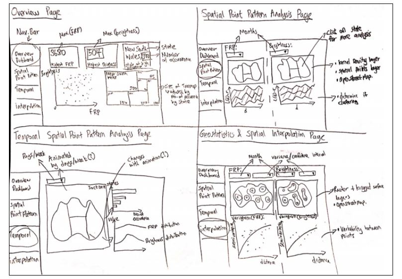

```r
knitr::include_graphics(rep('img/storyboard.jpg'))
```

## Project Scope of Work

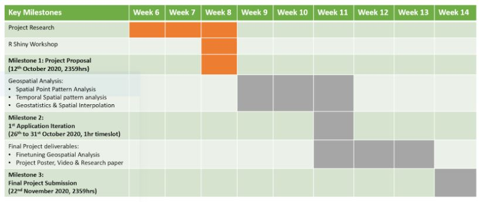

```r
knitr::include_graphics(rep('img/scope.jpg'))
```

## Application System Architecture

[figure not shown]

```r
knitr::include_graphics(rep('img/SA.jpg'))
```

## Tools & Packages

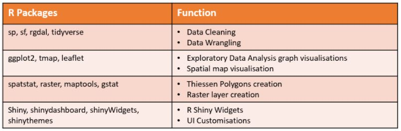

```r
knitr::include_graphics(rep('img/packages.jpg'))
```

## Challenges

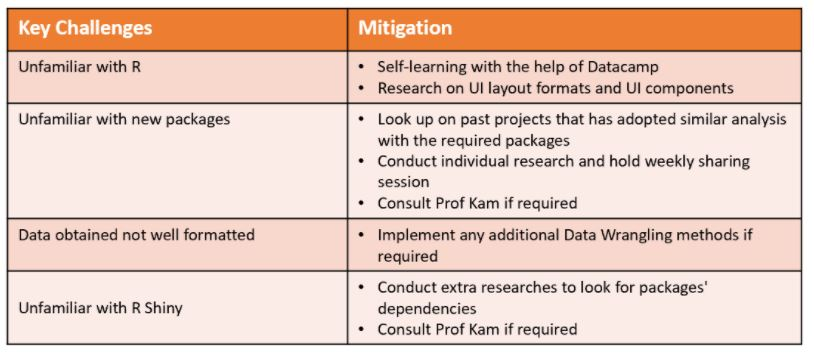

```r
knitr::include_graphics(rep('img/challenges.jpg'))
```